# Tutorial

James Thorson

2018-03-19

# Description

`FishLife` is an R package for predicting and repositing life-history parameters for >30,000 fishes using both life-history correlations and similarities among related species. This package uses data from FishBase as downloaded in 2016, and can be updated using a new database, or using additional data for a single species.

## Explore predictions online

A graphical user interface (GUI) is available [online](https://james-thorson.shinyapps.io/FishLife/)

# Example usage

## Load the package

First, install and load the package.

```r
# Install and load package
devtools::install_github("james-thorson/FishLife")
library( FishLife )
```

## Get predictions for a given taxon

Next, we show predictions using the database.

### Data-rich: red snapper

First we demonstrate red snapper, which is within the FishBase database used to train the model, so its predictions are relatively tight.

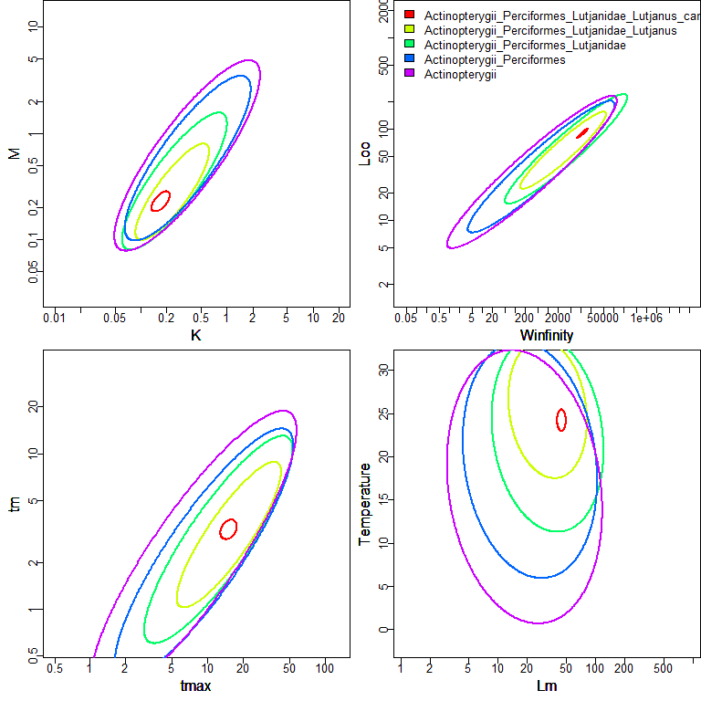

```r
# Get basic plot for Lutjanus campechanus
Plot_taxa( Search_species(Genus="Lutjanus",Species="campechanus")$match_taxonomy, mfrow=c(2,2) )
```

### Data-poor: Cortez rockfish

Next we demonstrate cortez rockfish, which is not within the FishBase database used to train the model, so its predictions are relatively based on information from related species within genus *Sebastes*.

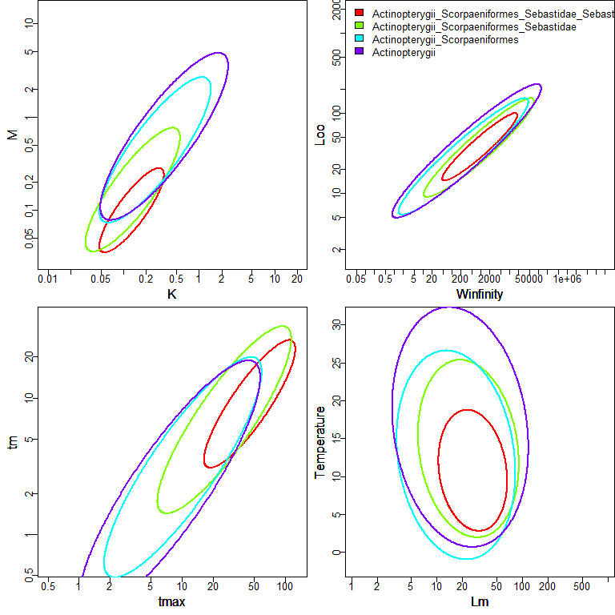

```r
# Get basic plot for Sebastes cortezi
Predict = Plot_taxa( Search_species(Genus="Sebastes",Species="cortezi")$match_taxonomy, mfrow=c(2,2) )
```

We then show updated values for the predictive mean using `Predict[[1]]$Mean_pred`…

| Loo | 3.638 |
| --- | --- |
| K | -2.053 |
| Winfinity | 6.836 |
| tmax | 3.819 |
| tm | 2.201 |
| M | -2.302 |
| Lm | 3.274 |
| Temperature | 10.793 |

… and predictive covariance using `Predict[[1]]$Cov_pred` …

|  | Loo | K | Winfinity | tmax | tm | M | Lm | Temperature |
| --- | --- | --- | --- | --- | --- | --- | --- | --- |
| Loo | 0.157 | -0.109 | 0.459 | 0.100 | 0.103 | -0.110 | 0.143 | -0.165 |
| K | -0.109 | 0.161 | -0.342 | -0.128 | -0.136 | 0.144 | -0.095 | 0.425 |
| Winfinity | 0.459 | -0.342 | 1.505 | 0.320 | 0.334 | -0.337 | 0.424 | -0.289 |
| tmax | 0.100 | -0.128 | 0.320 | 0.174 | 0.159 | -0.154 | 0.106 | -0.397 |
| tm | 0.103 | -0.136 | 0.334 | 0.159 | 0.194 | -0.138 | 0.117 | -0.407 |
| M | -0.110 | 0.144 | -0.337 | -0.154 | -0.138 | 0.181 | -0.107 | 0.508 |
| Lm | 0.143 | -0.095 | 0.424 | 0.106 | 0.117 | -0.107 | 0.143 | -0.207 |
| Temperature | -0.165 | 0.425 | -0.289 | -0.397 | -0.407 | 0.508 | -0.207 | 10.651 |

… for life-history parameters. These values are in log-space for all variables except Temperature, and converting to the predictive median can be accomplished by exponentiating those variables: :

| Loo | 38.009 |
| --- | --- |
| K | 0.128 |
| Winfinity | 930.756 |
| tmax | 45.574 |
| tm | 9.038 |
| M | 0.100 |
| Lm | 26.409 |
| Temperature | 10.793 |

… or the predictive mean can be calculated by exponentiating and bias-correcting:

| Loo | 41.120 |
| --- | --- |
| K | 0.139 |
| Winfinity | 1975.069 |
| tmax | 49.718 |
| tm | 9.958 |
| M | 0.110 |
| Lm | 28.368 |
| Temperature | 10.793 |

Please see code in “tutorial.Rmd” for details.

### High-level: Scombridae

Third, we demonstrate predictions for family *Scombridae*, to show how predictions are available for higher-level taxonomies.

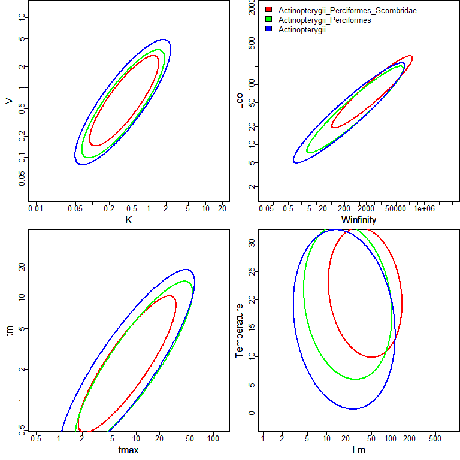

```r
# Get basic plot for Family Scombridae
Plot_taxa( Search_species(Family="Scombridae")$match_taxonomy, mfrow=c(2,2) )
```

### Comparison: Trouts

Fourth, we compare predictions for two species, brown and rainbow trout.

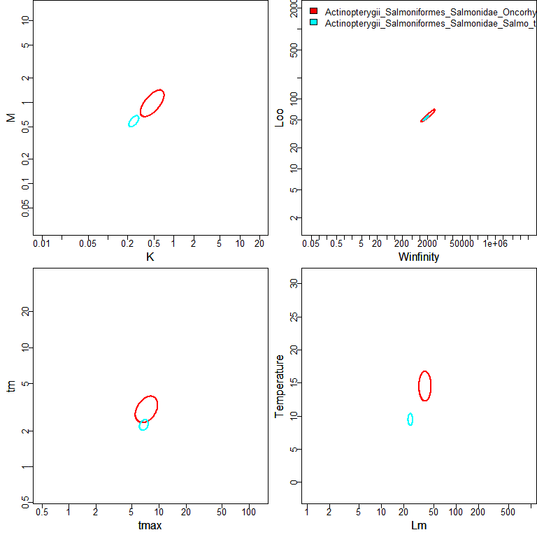

```r
# Compare two species
Taxa = c( Search_species(Genus="Oncorhynchus",Species="mykiss",add_ancestors=FALSE)$match_taxonomy,
  Search_species(Genus="Salmo",Species="Trutta",add_ancestors=FALSE)$match_taxonomy )
Plot_taxa( Taxa, mfrow=c(2,2) )
```

# How to update or replicate results

The package also contains tools to replicate results, explore model uncertainty, and include new data.

## How to re-run the model

We now show code for how the model can be re-run on the loaded database using a different structure on life-history correlations (although we do not run this, because it is slow).

```r
# Load TMB
library( TMB )

# Re-run results with a different model configuration
Estimate_database = Fit_model( N_factors=-3, N_obsfactors=-3, Use_REML=TRUE)
```

## Update predictions for a single taxon using user-supplied data

We also show how to generate new predictions for a single species based on new life-history information.

Specifically, we imagine a scenario where we have a new value for asymptotic length, which we format in a new dataframe `Ynew_ij` that can contain one or more parameters

```r
Ynew_ij = matrix( c("Loo"=log(40),"K"=NA,"Winfinity"=NA,"tmax"=NA,"tm"=NA,"M"=NA,"Lm"=NA,"Temperature"=NA), nrow=1)
```

Then run an updating function for Cortez rockfish

```r
library(TMB)
Update = Update_prediction( Taxon=Search_species(Genus="Sebastes",Species="cortezi",add_ancestors=FALSE)$match_taxonomy, Ynew_ij=Ynew_ij)
```

```
## Note: Using Makevars in C:/Users/James.Thorson/Documents/.R/Makevars
```

We then show updated values for the predictive mean using `Update$updateMean_j` …

| Loo | 3.674 |
| --- | --- |
| K | -2.078 |
| Winfinity | 6.942 |
| tmax | 3.842 |
| tm | 2.225 |
| M | -2.327 |
| Lm | 3.307 |
| Temperature | 10.755 |

… and predictive covariance using `Update$updateCov_j` …

|  | Loo | K | Winfinity | tmax | tm | M | Lm | Temperature |
| --- | --- | --- | --- | --- | --- | --- | --- | --- |
| Loo | 0.045 | -0.031 | 0.131 | 0.029 | 0.030 | -0.032 | 0.041 | -0.047 |
| K | -0.031 | 0.107 | -0.115 | -0.079 | -0.084 | 0.090 | -0.025 | 0.343 |
| Winfinity | 0.131 | -0.115 | 0.549 | 0.112 | 0.119 | -0.108 | 0.127 | 0.055 |
| tmax | 0.029 | -0.079 | 0.112 | 0.129 | 0.112 | -0.104 | 0.042 | -0.322 |
| tm | 0.030 | -0.084 | 0.119 | 0.112 | 0.145 | -0.087 | 0.050 | -0.330 |
| M | -0.032 | 0.090 | -0.108 | -0.104 | -0.087 | 0.126 | -0.036 | 0.426 |
| Lm | 0.041 | -0.025 | 0.127 | 0.042 | 0.050 | -0.036 | 0.051 | -0.100 |
| Temperature | -0.047 | 0.343 | 0.055 | -0.322 | -0.330 | 0.426 | -0.100 | 10.527 |

… for life-history parameters for this species. This update shows a change in asymptotic length (due to including new data) and also in relative growth rate (due to estimated covariance among traits).

# Description of package

If using the software or predictions please cite:

- Thorson, J. T., S. B. Munch, J. M. Cope, and J. Gao. In press. Predicting life history parameters for all fishes worldwide. Ecological Applications.

Also please see:

- Thorson, J. T., J. M. Cope, and W. S. Patrick. 2014. Assessing the quality of life history information in publicly available databases. Ecological Applications 24:217-226.

for further information regarding life-history predictions currently available in FishBase.